# Homework - Part 3: Understanding linear and tree-based models

## Machine Learning for Business Analytics (CIS432)

### Simon Business School

**Instructor**: Yaron Shaposhnik

### Instructions

In this homework assignment, you will train linear and tree-based models. You will experiment with their key hyper-parameters and observe how they affect the resulting models. This should improve your understanding of these models and help you create better ones.

## Answer key

This assignment (as well as others) is graded by comparing your answers (that is, the variables and Python objects you create) with precomputed answers. This allows you to get immediate feedback in order to find your errors and correct them. The downside of this approach is that the grading code is strict and even slight deviations from the desired outputs could result in reduction of points.

To make this learning experience more efficient, the objects that you are asked to generate are provided to you in the variable `ANSWER_KEY`. Questions may ask you to assign a value (like a number or object such as data frame) to a variable. For example, in the second question you are asked to assign the variable `n_rows` with a certain value. To view the correct answer simply run the command `ANSWER_KEY['n_rows']`.

Note that the answer key is provided to you **for debugging purposes only**. Using it in your final submission or hard-coding solutions **will be considered plagiarism** and be reported to the student disciplinary committee.

```python
# you may ignore this cell
from sklearn.model_selection import train_test_split
from sklearn.compose import ColumnTransformer
from sklearn.impute import SimpleImputer
from sklearn.pipeline import FeatureUnion
from sklearn.impute import MissingIndicator
from sklearn.pipeline import Pipeline
import os
from io import StringIO
import pandas as pd
import numpy as np
import matplotlib.pyplot as plt
import seaborn as sns
import pickle
import json
from os import path

if os.name == 'nt':
    ANSWER_KEY_FILE_NAME = "answer_key(win)-part3.p"
elif os.name == 'posix':
    ANSWER_KEY_FILE_NAME = "answer_key(unix)-part3.p"
else:
    raise Exception('The code was not tested on',os.name)

GENERATE_ANSWER_KEY=False

if GENERATE_ANSWER_KEY:
    ANSWER_KEY = {}
else:
    with open(ANSWER_KEY_FILE_NAME, "rb") as f:
        ANSWER_KEY = pickle.load( f )

def pandas_to_str(df):
    output = StringIO()
    df.to_csv(output)
    return( output.getvalue())

def str_to_pandas(s):
    data_io = StringIO(s)
    return(pd.read_csv(data_io, index_col=0).squeeze())
```

```python
# example for using answer key
if GENERATE_ANSWER_KEY==False:
    print(ANSWER_KEY['log_reg_coefficients'])
```

```
[-4.71608111e-02 -8.77351793e-04  4.14111077e-03 -7.38937484e-03
 -3.60491852e-02  1.48211467e-02 -2.61953210e-03 -1.08113746e-02
 -7.65910873e-03 -4.82940264e-02  1.64220247e-02  2.91180903e-03
  4.50144897e-03  6.50770419e-03 -6.13430166e-02  4.31814792e-01
 -3.81890066e-01  1.07203690e-02  3.58834085e-03  8.08987362e-02
 -1.65731082e-02  5.93746497e-02 -1.07490923e-03 -2.71475525e-01
  3.58535740e-01  1.54322580e-01  4.45170017e-01 -8.23389754e-01
  7.30953757e-03 -3.51758568e-02 -3.10953084e-01  3.15221120e-01
  5.24180408e-01 -8.40650316e-01  5.22031345e+00]
```

```python
###
### AUTOGRADER TEST - DO NOT REMOVE
###
```

# Beginning

In previous homework assignments you created and evaluated models based on the HELOC dataset. Let's reload the data.

```python
PREPROCESSED_DATA_FILE_NAME = "preprocessed_data.json"
with open(PREPROCESSED_DATA_FILE_NAME, 'r') as f:
    PREPROCESSED_DATA = json.load(f)
for d in ['X_train_t_tr','X_train_t_val','Y_train_t_tr','Y_train_t_val','X_test_t','Y_test']:
    PREPROCESSED_DATA[d] = str_to_pandas(PREPROCESSED_DATA[d])

X_train_t_tr,  Y_train_t_tr  = PREPROCESSED_DATA['X_train_t_tr'],  PREPROCESSED_DATA['Y_train_t_tr']
X_train_t_val, Y_train_t_val = PREPROCESSED_DATA['X_train_t_val'], PREPROCESSED_DATA['Y_train_t_val']
X_test_t,      Y_test        = PREPROCESSED_DATA['X_test_t'],      PREPROCESSED_DATA['Y_test']
n = len(Y_train_t_tr) + len(Y_train_t_val) + len(Y_test)
column_names = PREPROCESSED_DATA['column_names']

print('Train data:      X_train_t_tr:', X_train_t_tr.shape, ' Y_train_t_tr:', Y_train_t_tr.shape)
print('Validation data: X_train_t_val:', X_train_t_val.shape, 'Y_train_t_val:', Y_train_t_val.shape)
print('Test data:       X_test_t:', X_test_t.shape, '     Y_test:', Y_test.shape)
print('\nThe proportion of train,validation,test data is %.1f:%.1f:%.1f\n'%(len(Y_train_t_tr)/n, len(Y_train_t_val)/n, len(Y_test)/n))
print('column_names:',column_names)
```

```
Train data:      X_train_t_tr: (5916, 34)  Y_train_t_tr: (5916,)
Validation data: X_train_t_val: (1972, 34) Y_train_t_val: (1972,)
Test data:       X_test_t: (1973, 34)      Y_test: (1973,)

The proportion of train,validation,test data is 0.6:0.2:0.2

column_names: ['ExternalRiskEstimate', 'MSinceOldestTradeOpen', 'MSinceMostRecentTradeOpen', 'AverageMInFile', 'NumSatisfactoryTrades', 'NumTrades60Ever2DerogPubRec', 'NumTrades90Ever2DerogPubRec', 'PercentTradesNeverDelq', 'MSinceMostRecentDelq', 'MaxDelq2PublicRecLast12M', 'MaxDelqEver', 'NumTotal…
```

## Part 1: Linear models

Let's use the train set to train a few linear models and compare them.

```python
from sklearn.linear_model import LogisticRegression
from sklearn.discriminant_analysis import LinearDiscriminantAnalysis
from sklearn.linear_model import SGDClassifier
```

```python
log_reg = LogisticRegression(max_iter=10000, random_state=0).fit(X_train_t_tr, Y_train_t_tr) # Logistic regression
svc     = SGDClassifier(max_iter=1000, random_state=0).fit(X_train_t_tr, Y_train_t_tr)       # Linear SVM
lda     = LinearDiscriminantAnalysis().fit(X_train_t_tr, Y_train_t_tr)                       # LDA
```

```python
print('Train accuracy')
print('Log. Reg. accuracy: %.3f'%log_reg.score(X_train_t_tr, Y_train_t_tr))
print('Linear SVC accuracy: %.3f'%svc.score(X_train_t_tr, Y_train_t_tr))
print('LDA accuracy: %.3f'%lda.score(X_train_t_tr, Y_train_t_tr))

print('\nValidation accuracy')
print('Log. Reg. accuracy: %.3f'%log_reg.score(X_train_t_val, Y_train_t_val))
print('Linear SVC accuracy: %.3f'%svc.score(X_train_t_val, Y_train_t_val))
print('LDA accuracy: %.3f'%lda.score(X_train_t_val, Y_train_t_val))
```

```
Train accuracy
Log. Reg. accuracy: 0.742
Linear SVC accuracy: 0.696
LDA accuracy: 0.742

Validation accuracy
Log. Reg. accuracy: 0.731
Linear SVC accuracy: 0.689
LDA accuracy: 0.731
```

### q1

Initialize the variables `log_reg_coefficients`, `svc_coefficients`, and `lda_coefficients` so that each holds an array with the linear coefficients followed by the intercept corresponding to each model (that is, the intercept should be stored as the last element of `log_reg_coefficients` and the other arrays).

```python
log_reg_coefficients = np.append(log_reg.coef_, log_reg.intercept_)  # Logistic Regression
svc_coefficients = np.append(svc.coef_, svc.intercept_)  # Linear SVM
lda_coefficients = np.append(lda.coef_, lda.intercept_)  # LDA

print("Logistic Regression Coefficients:", log_reg_coefficients)
print("SVC Coefficients:", svc_coefficients)
print("LDA Coefficients:", lda_coefficients)
```

```
Logistic Regression Coefficients: [-4.71608111e-02 -8.77351793e-04  4.14111077e-03 -7.38937484e-03
 -3.60491852e-02  1.48211467e-02 -2.61953210e-03 -1.08113746e-02
 -7.65910873e-03 -4.82940264e-02  1.64220247e-02  2.91180903e-03
  4.50144897e-03  6.50770419e-03 -6.13430166e-02  4.31814792e-01
 -3.81890066e-01  1.07203690e-02  3.58834085e-03  8.08987362e-02
 -1.65731082e-02  5.93746497e-02 -1.07490923e-03 -2.71475525e-01
  3.58535740e-01  1.54322580e-01  4.45170017e-01 -8.23389754e-01
  7.30953757e-03 -3.51758568e-02 -3.10953084e-01  3.15221120e-01
  5.24180408e-01 -8.40650316e-01  5.22031345e+00]
SVC Coefficients: [ 7.80893870e-02 -1.04646786e+00  2.00104054e+00 -1.66916065e+00
 -1.15474681e+01  4.08602717e+01 -4.18754338e+00 -9.76117337e-01
 -4.95746531e+00 -2.71263008e+01 -5.46625709e+00  8.19938563e-01
  9.39024878e+00  7.51610350e-01 -1.54015679e+01  3.50426124e+01
 -1.11179765e+01  5.12615341e+00  2.42490342e+00  2.47530637e+01
  5.16648254e-01  4.01858801e+01  4.28760872e+00 -1.01779755e+02
  7.91435937e+01  1.42025073e+01  1.36070757e+01 -6.32719258e+01
 -5.95431576e-01  1.14303340e+01 -2.89906849e+00  2.07229711e+01
  3.22313945e+01 -2.64527798e+00  3.93563359e+02]
LDA Coefficients: [-5.93939402e-02 -8.99118499e-04  3.86458330e-03 -7.23728180e-03
 -4.09262137e-02  1.31738598e-02 -1.37064335e-02 -7.01114185e-03
 -8.53145267e-03 -3.83480911e-02  2.02966137e-03  3.28097385e-03
  1.00587920e-02  6.51897436e-03 -6.07673397e-02  4.27437228e-01
 -3.88847852e-01  1.03133467e-02  3.44232641e-03  8.56650319e-02
 -1.04816741e-02  6.85647790e-02 -1.41643515e-03 -2.95454445e-01
  3.83395604e-01  1.55519498e-01  5.04180199e-01 -7.30727293e-01
  6.59979891e-02 -5.36120574e-02 -4.25225486e-01  3.34261541e-01
  5.16327965e-01 -2.07076276e+00  5.92313709e+00]
```

```python
# example
ANSWER_KEY['log_reg_coefficients']
```

```
array([-4.71608111e-02, -8.77351793e-04,  4.14111077e-03, -7.38937484e-03,
       -3.60491852e-02,  1.48211467e-02, -2.61953210e-03, -1.08113746e-02,
       -7.65910873e-03, -4.82940264e-02,  1.64220247e-02,  2.91180903e-03,
        4.50144897e-03,  6.50770419e-03, -6.13430166e-02,  4.31814792e-01,
       -3.81890066e-01,  1.07203690e-02,  3.58834085e-03,  8.08987362e-02,
       -1.65731082e-02,  5.93746497e-02, -1.07490923e-03, -2.71475525e-01,
        3.58535740e-01,  1.54322580e-01,  4.45170017e-01, -8.23389754e-01,
        7.30953757e-03, -3.51758568e-02, -3.10953084e-01,  3.15221120e-01,
        5.24180408e-01, -8.40650316e-01,  5.22031345e+00])
```

```python
### BEGIN TEST
assert(np.isclose(ANSWER_KEY['log_reg_coefficients'], log_reg_coefficients, rtol=0, atol=0.01).all()), 'testing log_reg_coefficients'
### END TEST
```

```python
### BEGIN TEST
assert(np.isclose(ANSWER_KEY['svc_coefficients'], svc_coefficients, rtol=0, atol=0.01).all()), 'testing svc_coefficients'
### END TEST
```

```python
### BEGIN TEST
assert(np.isclose(ANSWER_KEY['lda_coefficients'], lda_coefficients, rtol=0, atol=0.01).all()), 'testing lda_coefficients'
### END TEST
```

### q2

```python
log_reg_coefficients = np.append(log_reg.coef_.flatten(), log_reg.intercept_.item())
svc_coefficients = np.append(svc.coef_.flatten(), svc.intercept_.item())
lda_coefficients = np.append(lda.coef_.flatten(), lda.intercept_.item())

row_labels = column_names + ["intercept"]

linear_coefficients = pd.DataFrame(
    np.column_stack([log_reg_coefficients, svc_coefficients, lda_coefficients]),
    columns=["Log. Reg.", "SVC", "LDA"],
    index=row_labels
)

print(linear_coefficients)
```

```
                                       Log. Reg.         SVC       LDA
ExternalRiskEstimate                   -0.047161    0.078089 -0.059394
MSinceOldestTradeOpen                  -0.000877   -1.046468 -0.000899
MSinceMostRecentTradeOpen               0.004141    2.001041  0.003865
AverageMInFile                         -0.007389   -1.669161 -0.007237
NumSatisfactoryTrades                  -0.036049  -11.547468 -0.040926
NumTrades60Ever2DerogPubRec             0.014821   40.860272  0.013174
NumTrades90Ever2DerogPubRec            -0.002620   -4.187543 -0.013706
PercentTradesNeverDelq                 -0.010811   -0.976117 -0.007011
MSinceMostRecentDelq                   -0.007659   -4.957465 -0.008531
MaxDelq2PublicRecLast12M               -0.048294  -27.126301 -0.038348
MaxDelqEver                             0.016422   -5.466257  0.002030
NumTotalTrades                          0.002912    0.819939  0.003281
NumTradesOpeninLast12M                  0.004501    9.390249  0.010059
PercentInstallTrades                    0.006508    0.751610  0.006519
MSinceMostRecentInqexcl7days           -0.061343  -15.401568 -0.060767
NumInqLast6M                            0.431815   35.042612  0.427437
NumInqLast6Mexcl7days                  -0.381890  -11.117976 -0.388848
NetFractionRevolvingBurden              0.010720    5.126153  0.010313
NetFractionInstallBurden                0.003588    2.424903  0.003442
NumRevolvingTradesWBalance              0.080899   24.753064  0.085665
NumInstallTradesWBalance               -0.016573    0.516648 -0.010482
NumBank2NatlTradesWHighUtilization      0.059375   40.185880  0.068565
PercentTradesWBalance                  -0.001075    4.287609 -0.001416
MSinceMostRecentDelq=-7                -0.271476 -101.779755 -0.295454
MSinceMostRecentInqexcl7days=-7         0.358536   79.143594  0.383396
MSinceOldestTradeOpen=-8                0.154323   14.202507  0.155519
MSinceMostRecentDelq=-8                 0.445170   13.607076  0.504180
MSinceMostRecentInqexcl7days=-8        -0.823390  -63.271926 -0.730727
NetFractionRevolvingBurden=-8           0.007310   -0.595432  0.065998
NetFractionInstallBurden=-8            -0.035176   11.430334 -0.053612
NumRevolvingTradesWBalance=-8          -0.310953   -2.899068 -0.425225
NumInstallTradesWBalance=-8             0.315221   20.722971  0.334262
NumBank2NatlTradesWHighUtilization=-8   0.524180   32.231394  0.516328
PercentTradesWBalance=-8               -0.840650   -2.645278 -2.070763
intercept                               5.220313  393.563359  5.923137
```

```python
# expected output
ANSWER_KEY['linear_coefficients'].head()
```

|  | Log. Reg. | SVC | LDA |
| --- | --- | --- | --- |
| ExternalRiskEstimate | -0.047161 | 0.078089 | -0.059394 |
| MSinceOldestTradeOpen | -0.000877 | -1.046468 | -0.000899 |
| MSinceMostRecentTradeOpen | 0.004141 | 2.001041 | 0.003865 |
| AverageMInFile | -0.007389 | -1.669161 | -0.007237 |
| NumSatisfactoryTrades | -0.036049 | -11.547468 | -0.040926 |

```python
### BEGIN TEST (DO NOT REMOVE CELL)
sol = ANSWER_KEY['linear_coefficients'].round(2)
diff = sol.compare(linear_coefficients.round(2), keep_equal=False, align_axis=0)
assert(len(diff)==0), 'testing linear_coefficients'
### END TEST
```

### q3

Linear classifiers are equivalent up to a multiplication by a constant. Let's divide each classifier by its intercept to see if the models are different.

Create the dataframe `linear_coefficients_scaled` which holds the linear coefficients scaled by their intercept values.

```python
# Ensure the index labels match correctly with expected output
row_labels = column_names + ["Intercept"]  # Define correct row labels

# Scale each classifier's coefficients by its intercept value
log_reg_scaled = log_reg_coefficients / log_reg_coefficients[-1]  # Divide by last element (intercept)
svc_scaled = svc_coefficients / svc_coefficients[-1]  # Divide by last element (intercept)
lda_scaled = lda_coefficients / lda_coefficients[-1]  # Divide by last element (intercept)

# Create DataFrame for scaled coefficients with correct index
linear_coefficients_scaled = pd.DataFrame(
    np.column_stack([log_reg_scaled, svc_scaled, lda_scaled]),
    columns=["Log. Reg.", "SVC", "LDA"],
    index=row_labels
)

# Rename "Intercept" to "intercept" to match expected output
linear_coefficients_scaled.rename(index={"Intercept": "intercept"}, inplace=True)
```

```python
# expected output
ANSWER_KEY['linear_coefficients_scaled'].head()
```

|  | Log. Reg. | SVC | LDA |
| --- | --- | --- | --- |
| ExternalRiskEstimate | -0.009034 | 0.000198 | -0.010027 |
| MSinceOldestTradeOpen | -0.000168 | -0.002659 | -0.000152 |
| MSinceMostRecentTradeOpen | 0.000793 | 0.005084 | 0.000652 |
| AverageMInFile | -0.001416 | -0.004241 | -0.001222 |
| NumSatisfactoryTrades | -0.006906 | -0.029341 | -0.006910 |

```python
### BEGIN TEST (DO NOT REMOVE CELL)
sol = ANSWER_KEY['linear_coefficients_scaled'].round(2)
diff = sol.compare(linear_coefficients_scaled.round(2), keep_equal=False, align_axis=0)
assert(len(diff)==0), 'testing linear_coefficients_scaled'
### END TEST
```

By examining `linear_coefficients_scaled`, we see that the resulting linear models are indeed different. We can also see it in the figure below.

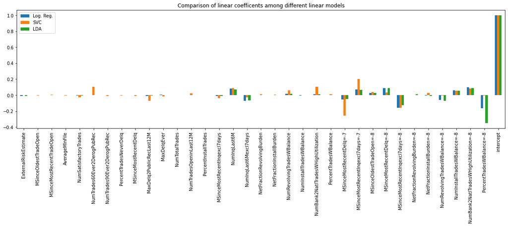

```python
ANSWER_KEY['linear_coefficients_scaled'].plot.bar(figsize=(20,5))
plt.title('Comparison of linear coefficents among different linear models');
```

We also observe that the models are not identical by looking at their predictions. (Note that the models could be quite similar to each other, which is often the case).

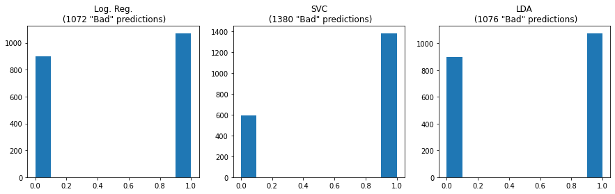

```python
fig, axes = plt.subplots(1,3,figsize=(15,4))
axes[0].hist(log_reg.predict(X_train_t_val))
axes[1].hist(svc.predict(X_train_t_val))
axes[2].hist(lda.predict(X_train_t_val));
axes[0].set_title('Log. Reg.\n (%d "Bad" predictions)'%sum(log_reg.predict(X_train_t_val)))
axes[1].set_title('SVC\n (%d "Bad" predictions)'%sum(svc.predict(X_train_t_val)))
axes[2].set_title('LDA\n (%d "Bad" predictions)'%sum(lda.predict(X_train_t_val)));
```

Next, let us manually compute the predictions that each model makes. To this end, for a given observation $x$, we will need to multiply each feature of $x$ by its respective coefficient and then add the intercept.

```python
# example of manually computing the prediction of the logistic regression model
# we will work with the first observation in the data
observation = X_train_t_val.iloc[0]

# element-wise multiplication by coefficients, summation, and addition of the intercept
sum(observation*log_reg_coefficients[:-1]) + log_reg_coefficients[-1]
```

```
1.5260519564476684
```

```python
# an equivalent way using np.dot (inner product)
np.dot(X_train_t_val.iloc[0],log_reg_coefficients[:-1]) + log_reg_coefficients[-1]
```

```
1.526051956447668
```

```python
log_reg_coefficients.shape
```

```
(35,)
```

The first 34 values of `log_reg_coefficients` hold the linear coefficients and the last value is the intercept. Since the linear function returned a positive value, the prediction is `1`, otherwise, the prediction would have been `0`. In the next cell, we apply the linear function to the first 4 observations in `X_train_t_val`:

```python
np.dot(X_train_t_val.iloc[:4,:],log_reg_coefficients[:-1]) + log_reg_coefficients[-1]
```

```
array([ 1.52605196, -0.40844485,  0.34132803, -1.94507808])
```

We can compare each the result with 0 to see if the predictions are `1` or `0`:

```python
(np.dot(X_train_t_val.iloc[:4,:],log_reg_coefficients[:-1]) + log_reg_coefficients[-1] >0).astype(int)
```

```
array([1, 0, 1, 0])
```

And this is exactly what we get when we use the logistic regression model prediction function `.predict()`

```python
log_reg.predict(X_train_t_val.iloc[:4,:])
```

```
array([1, 0, 1, 0])
```

As a sanity check, we compare the predictions on all datasets:

```python
for X in [X_train_t_tr, X_train_t_val, X_test_t]: # compare train, validation and test sets
    print(((np.dot(X,log_reg_coefficients[:-1]) + log_reg_coefficients[-1] >0).astype(int) == log_reg.predict(X)).all())
```

```
True
True
True
```

### q4

Using the function `np.dot` and `np.mean` compute the validation set accuracy of the logistic regression model. Assign the answer to the variable `log_reg_val_accuracy` (you should not use the function `.predict()` or any other sk-learn functions).

```python
# Compute the validation set accuracy manually using np.dot and np.mean
log_reg_predictions_manual = (np.dot(X_train_t_val, log_reg_coefficients[:-1]) + log_reg_coefficients[-1] > 0).astype(int)
log_reg_val_accuracy = np.mean(log_reg_predictions_manual == Y_train_t_val)

# Display the result
print(log_reg_val_accuracy)
```

```
0.731237322515213
```

```python
### BEGIN TEST
assert(np.isclose(ANSWER_KEY['log_reg_val_accuracy'], log_reg_val_accuracy, rtol=0, atol=0.01).all()), 'testing log_reg_val_accuracy'
### END TEST
```

```python
# expected answer
ANSWER_KEY['log_reg_val_accuracy']
```

```
0.731237322515213
```

Let us now take a closer look at the coefficients of the logistic regression model.

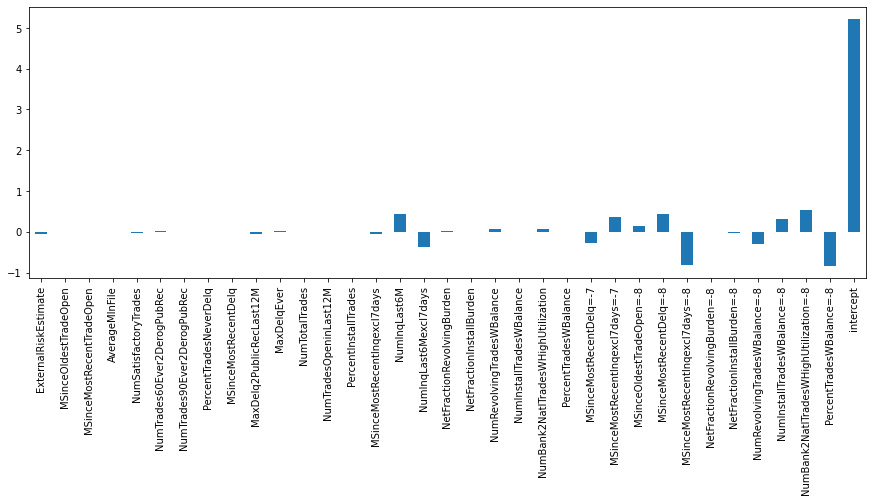

```python
linear_coefficients['Log. Reg.'].plot.bar(figsize=(15,5));
```

Some of the coefficients are considerably smaller than others.

```python
linear_coefficients['Log. Reg.']
```

```
ExternalRiskEstimate                    -0.047161
MSinceOldestTradeOpen                   -0.000877
MSinceMostRecentTradeOpen                0.004141
AverageMInFile                          -0.007389
NumSatisfactoryTrades                   -0.036049
NumTrades60Ever2DerogPubRec              0.014821
NumTrades90Ever2DerogPubRec             -0.002620
PercentTradesNeverDelq                  -0.010811
MSinceMostRecentDelq                    -0.007659
MaxDelq2PublicRecLast12M                -0.048294
MaxDelqEver                              0.016422
NumTotalTrades                           0.002912
NumTradesOpeninLast12M                   0.004501
PercentInstallTrades                     0.006508
MSinceMostRecentInqexcl7days            -0.061343
NumInqLast6M                             0.431815
NumInqLast6Mexcl7days                   -0.381890
NetFractionRevolvingBurden               0.010720
NetFractionInstallBurden                 0.003588
NumRevolvingTradesWBalance               0.080899
NumInstallTradesWBalance                -0.016573
NumBank2NatlTradesWHighUtilization       0.059375
PercentTradesWBalance                   -0.001075
MSinceMostRecentDelq=-7                 -0.271476
MSinceMostRecentInqexcl7days=-7          0.358536
MSinceOldestTradeOpen=-8                 0.154323
MSinceMostRecentDelq=-8                  0.445170
MSinceMostRecentInqexcl7days=-8         -0.823390
NetFractionRevolvingBurden=-8            0.007310
NetFractionInstallBurden=-8             -0.035176
NumRevolvingTradesWBalance=-8           -0.310953
NumInstallTradesWBalance=-8              0.315221
NumBank2NatlTradesWHighUtilization=-8    0.524180
PercentTradesWBalance=-8                -0.840650
intercept                                5.220313
Name: Log. Reg., dtype: float64
```

Does this mean we can ignore them? Let's try.

### q5

The coefficient associated with `ExternalRiskEstimate` is an order of magnitude smaller than some of the other coefficients. Create the pandas series `modified_log_reg` which is identical to `linear_coefficients['Log. Reg.']` with the difference that the coefficient associated with `ExternalRiskEstimate` is set to 0.

```python
# Create a copy of the 'Log. Reg.' coefficients
modified_log_reg = linear_coefficients['Log. Reg.'].copy()

# Set the coefficient associated with 'ExternalRiskEstimate' to 0
modified_log_reg.loc['ExternalRiskEstimate'] = 0

# Display the result
print(modified_log_reg)
```

```
ExternalRiskEstimate                     0.000000
MSinceOldestTradeOpen                   -0.000877
MSinceMostRecentTradeOpen                0.004141
AverageMInFile                          -0.007389
NumSatisfactoryTrades                   -0.036049
NumTrades60Ever2DerogPubRec              0.014821
NumTrades90Ever2DerogPubRec             -0.002620
PercentTradesNeverDelq                  -0.010811
MSinceMostRecentDelq                    -0.007659
MaxDelq2PublicRecLast12M                -0.048294
MaxDelqEver                              0.016422
NumTotalTrades                           0.002912
NumTradesOpeninLast12M                   0.004501
PercentInstallTrades                     0.006508
MSinceMostRecentInqexcl7days            -0.061343
NumInqLast6M                             0.431815
NumInqLast6Mexcl7days                   -0.381890
NetFractionRevolvingBurden               0.010720
NetFractionInstallBurden                 0.003588
NumRevolvingTradesWBalance               0.080899
NumInstallTradesWBalance                -0.016573
NumBank2NatlTradesWHighUtilization       0.059375
PercentTradesWBalance                   -0.001075
MSinceMostRecentDelq=-7                 -0.271476
MSinceMostRecentInqexcl7days=-7          0.358536
MSinceOldestTradeOpen=-8                 0.154323
MSinceMostRecentDelq=-8                  0.445170
MSinceMostRecentInqexcl7days=-8         -0.823390
NetFractionRevolvingBurden=-8            0.007310
NetFractionInstallBurden=-8             -0.035176
NumRevolvingTradesWBalance=-8           -0.310953
NumInstallTradesWBalance=-8              0.315221
NumBank2NatlTradesWHighUtilization=-8    0.524180
PercentTradesWBalance=-8                -0.840650
intercept                                5.220313
Name: Log. Reg., dtype: float64
```

```python
### BEGIN TEST (DO NOT REMOVE CELL)
sol = ANSWER_KEY['modified_log_reg'].round(2)
diff = sol.compare(modified_log_reg.round(2), keep_equal=False, align_axis=0)
assert(len(diff)==0), 'testing modified_log_reg'
### END TEST
```

Compute the prediction accuracy on the validation set of the new model represented by `modified_log_reg` and assign the answer to the variable `accuracy_modified_log_reg`.

```python
# Compute the validation set predictions manually using modified_log_reg
modified_log_reg_predictions = (np.dot(X_train_t_val, modified_log_reg[:-1]) + modified_log_reg[-1] > 0).astype(int)

# Compute the accuracy
accuracy_modified_log_reg = np.mean(modified_log_reg_predictions == Y_train_t_val)

# Display the result
print(accuracy_modified_log_reg)
```

```
0.5172413793103449
```

```python
### BEGIN TEST
assert(np.isclose(ANSWER_KEY['accuracy_modified_log_reg'], accuracy_modified_log_reg, rtol=0, atol=0.01).all()), 'testing accuracy_modified_log_reg'
### END TEST
```

```python
ANSWER_KEY['accuracy_modified_log_reg']
```

```
0.5172413793103449
```

The new model is not performing well. The reason is that the magnitude of the features is different:

```python
X_train_t_tr.mean()
```

```
ExternalRiskEstimate                      72.018594
MSinceOldestTradeOpen                    200.649822
MSinceMostRecentTradeOpen                  9.546653
AverageMInFile                            78.911765
NumSatisfactoryTrades                     21.218222
NumTrades60Ever2DerogPubRec                0.584686
NumTrades90Ever2DerogPubRec                0.385565
PercentTradesNeverDelq                    92.225490
MSinceMostRecentDelq                      21.674075
MaxDelq2PublicRecLast12M                   5.745267
MaxDelqEver                                6.365281
NumTotalTrades                            22.770791
NumTradesOpeninLast12M                     1.868154
PercentInstallTrades                      34.778059
MSinceMostRecentInqexcl7days               2.524132
NumInqLast6M                               1.492563
NumInqLast6Mexcl7days                      1.430696
NetFractionRevolvingBurden                35.067740
NetFractionInstallBurden                  68.525181
NumRevolvingTradesWBalance                 4.094964
NumInstallTradesWBalance                   2.495542
NumBank2NatlTradesWHighUtilization         1.101812
PercentTradesWBalance                     66.654802
MSinceMostRecentDelq=-7                    0.471602
MSinceMostRecentInqexcl7days=-7            0.185429
MSinceOldestTradeOpen=-8                   0.024848
MSinceMostRecentDelq=-8                    0.015889
MSinceMostRecentInqexcl7days=-8            0.049527
NetFractionRevolvingBurden=-8              0.016227
NetFractionInstallBurden=-8                0.343813
NumRevolvingTradesWBalance=-8              0.014199
NumInstallTradesWBalance=-8                0.084517
NumBank2NatlTradesWHighUtilization=-8      0.054429
PercentTradesWBalance=-8                   0.001014
dtype: float64
```

The average value of `ExternalRiskEstimate` is among the highest. We can compute the average contribution of each feature to the linear function:

```python
(X_train_t_val* log_reg.coef_[0]).mean().abs().sort_values(ascending=False)
```

```
ExternalRiskEstimate                     3.395244
PercentTradesNeverDelq                   0.998709
NumSatisfactoryTrades                    0.761841
NumInqLast6M                             0.595169
AverageMInFile                           0.580976
NumInqLast6Mexcl7days                    0.507573
NetFractionRevolvingBurden               0.372924
NumRevolvingTradesWBalance               0.334466
MaxDelq2PublicRecLast12M                 0.278254
NetFractionInstallBurden                 0.245431
PercentInstallTrades                     0.223051
MSinceOldestTradeOpen                    0.177660
MSinceMostRecentDelq                     0.168381
MSinceMostRecentInqexcl7days             0.145168
MSinceMostRecentDelq=-7                  0.128992
MaxDelqEver                              0.104778
PercentTradesWBalance                    0.070843
NumBank2NatlTradesWHighUtilization       0.066551
MSinceMostRecentInqexcl7days=-7          0.066362
NumTotalTrades                           0.065674
NumInstallTradesWBalance                 0.041075
MSinceMostRecentTradeOpen                0.039412
NumBank2NatlTradesWHighUtilization=-8    0.038277
MSinceMostRecentInqexcl7days=-8          0.032568
NumInstallTradesWBalance=-8              0.029732
NetFractionInstallBurden=-8              0.012611
NumTrades60Ever2DerogPubRec              0.008711
NumTradesOpeninLast12M                   0.008361
MSinceMostRecentDelq=-8                  0.008127
NumRevolvingTradesWBalance=-8            0.005992
MSinceOldestTradeOpen=-8                 0.004069
NumTrades90Ever2DerogPubRec              0.001015
PercentTradesWBalance=-8                 0.000426
NetFractionRevolvingBurden=-8            0.000171
dtype: float64
```

We see that on average, `ExternalRiskEstimate` has a large impact on the predictions, despite it's relative small coefficient value (shown below)

```python
linear_coefficients['Log. Reg.'].abs().sort_values(ascending=False)
```

```
intercept                                5.220313
PercentTradesWBalance=-8                 0.840650
MSinceMostRecentInqexcl7days=-8          0.823390
NumBank2NatlTradesWHighUtilization=-8    0.524180
MSinceMostRecentDelq=-8                  0.445170
NumInqLast6M                             0.431815
NumInqLast6Mexcl7days                    0.381890
MSinceMostRecentInqexcl7days=-7          0.358536
NumInstallTradesWBalance=-8              0.315221
NumRevolvingTradesWBalance=-8            0.310953
MSinceMostRecentDelq=-7                  0.271476
MSinceOldestTradeOpen=-8                 0.154323
NumRevolvingTradesWBalance               0.080899
MSinceMostRecentInqexcl7days             0.061343
NumBank2NatlTradesWHighUtilization       0.059375
MaxDelq2PublicRecLast12M                 0.048294
ExternalRiskEstimate                     0.047161
NumSatisfactoryTrades                    0.036049
NetFractionInstallBurden=-8              0.035176
NumInstallTradesWBalance                 0.016573
MaxDelqEver                              0.016422
NumTrades60Ever2DerogPubRec              0.014821
PercentTradesNeverDelq                   0.010811
NetFractionRevolvingBurden               0.010720
MSinceMostRecentDelq                     0.007659
AverageMInFile                           0.007389
NetFractionRevolvingBurden=-8            0.007310
PercentInstallTrades                     0.006508
NumTradesOpeninLast12M                   0.004501
MSinceMostRecentTradeOpen                0.004141
NetFractionInstallBurden                 0.003588
NumTotalTrades                           0.002912
NumTrades90Ever2DerogPubRec              0.002620
PercentTradesWBalance                    0.001075
MSinceOldestTradeOpen                    0.000877
Name: Log. Reg., dtype: float64
```

Let's try something different. Let's train another logistic model but this time train it without `ExternalRiskEstimate` which happens to be the first feature. initialize the variables `X_train_t_tr_wo_ExternalRiskEstimate` and `Y_train_t_tr_wo_ExternalRiskEstimate` to hold the train data without the feature `ExternalRiskEstimate` (based on `X_train_t_tr` and `Y_train_t_tr`). Similarly, create the variables `X_train_t_val_wo_ExternalRiskEstimate` and `Y_train_t_val_wo_ExternalRiskEstimate` corresponding to the validation set (based on `X_train_t_val` and `Y_train_t_val`).

Observe that no changes are made to the labels here.

```python
# Remove the feature 'ExternalRiskEstimate' from the training and validation sets
X_train_t_tr_wo_ExternalRiskEstimate = X_train_t_tr.drop(columns=['ExternalRiskEstimate'])
Y_train_t_tr_wo_ExternalRiskEstimate = Y_train_t_tr  # Labels remain unchanged

X_train_t_val_wo_ExternalRiskEstimate = X_train_t_val.drop(columns=['ExternalRiskEstimate'])
Y_train_t_val_wo_ExternalRiskEstimate = Y_train_t_val  # Labels remain unchanged

# Display shapes to confirm correctness
print(X_train_t_tr_wo_ExternalRiskEstimate.shape, Y_train_t_tr_wo_ExternalRiskEstimate.shape)
print(X_train_t_val_wo_ExternalRiskEstimate.shape, Y_train_t_val_wo_ExternalRiskEstimate.shape)
```

```
(5916, 33) (5916,)
(1972, 33) (1972,)
```

```python
### BEGIN TEST (DO NOT REMOVE CELL)
sol = ANSWER_KEY['X_train_t_tr_wo_ExternalRiskEstimate'].round(2)
diff = sol.compare(X_train_t_tr_wo_ExternalRiskEstimate.round(2), keep_equal=False, align_axis=0)
assert(len(diff)==0), 'testing X_train_t_tr_wo_ExternalRiskEstimate'
### END TEST
```

```python
### BEGIN TEST (DO NOT REMOVE CELL)
sol = ANSWER_KEY['Y_train_t_tr_wo_ExternalRiskEstimate'].round(2)
diff = sol.compare(Y_train_t_tr_wo_ExternalRiskEstimate.round(2), keep_equal=False, align_axis=0)
assert(len(diff)==0), 'testing Y_train_t_tr_wo_ExternalRiskEstimate'
### END TEST
```

```python
### BEGIN TEST (DO NOT REMOVE CELL)
sol = ANSWER_KEY['X_train_t_val_wo_ExternalRiskEstimate'].round(2)
diff = sol.compare(X_train_t_val_wo_ExternalRiskEstimate.round(2), keep_equal=False, align_axis=0)
assert(len(diff)==0), 'testing X_train_t_val_wo_ExternalRiskEstimate'
### END TEST
```

```python
### BEGIN TEST (DO NOT REMOVE CELL)
sol = ANSWER_KEY['Y_train_t_val_wo_ExternalRiskEstimate'].round(2)
diff = sol.compare(Y_train_t_val_wo_ExternalRiskEstimate.round(2), keep_equal=False, align_axis=0)
assert(len(diff)==0), 'testing Y_train_t_val_wo_ExternalRiskEstimate'
### END TEST
```

```python
# Sanity check:
print('dimensions of X_train_t_tr:',X_train_t_tr.shape)
print('dimensions of X_train_t_tr_wo_ExternalRiskEstimate:',ANSWER_KEY['X_train_t_tr_wo_ExternalRiskEstimate'].shape)
```

```
dimensions of X_train_t_tr: (5916, 34)
dimensions of X_train_t_tr_wo_ExternalRiskEstimate: (5916, 33)
```

Now let's train and evaluate the model that does not use the feature `ExternalRiskEstimate`.

```python
log_reg_wo_ExternalRiskEstimate = LogisticRegression(max_iter=10000).fit(ANSWER_KEY['X_train_t_tr_wo_ExternalRiskEstimate'],
                                                                         ANSWER_KEY['Y_train_t_tr_wo_ExternalRiskEstimate'])
```

Compute the train and validation accuracies of the new linear model `log_reg_wo_ExternalRiskEstimate` and assign the results to the variables `accuracy_retrained_model_train` and `accuracy_retrained_model_validation`. Create the variable `retrained_log_reg` which is a pandas series whose indexes are similar to that of `modified_log_reg` and whose values are used by the linear classifier `log_reg_wo_ExternalRiskEstimate`.

Note that while the feature `ExternalRiskEstimate` is not needed for the model `log_reg_wo_ExternalRiskEstimate`, we keep it to make it easier to compare it with other models. The coefficient associated with `ExternalRiskEstimate` should simply be set equal to 0.

```python
# Train a logistic regression model without 'ExternalRiskEstimate'
log_reg_wo_ExternalRiskEstimate = LogisticRegression(max_iter=10000).fit(
    X_train_t_tr_wo_ExternalRiskEstimate, Y_train_t_tr_wo_ExternalRiskEstimate
)

# Compute train and validation accuracies
accuracy_retrained_model_train = log_reg_wo_ExternalRiskEstimate.score(
    X_train_t_tr_wo_ExternalRiskEstimate, Y_train_t_tr_wo_ExternalRiskEstimate
)
accuracy_retrained_model_validation = log_reg_wo_ExternalRiskEstimate.score(
    X_train_t_val_wo_ExternalRiskEstimate, Y_train_t_val_wo_ExternalRiskEstimate
)

# Get the list of features excluding 'ExternalRiskEstimate'
feature_names_without_external_risk = [col for col in modified_log_reg.index if col != 'ExternalRiskEstimate']

# Create a Pandas Series for the new model coefficients
retrained_log_reg = pd.Series(
    data=np.append(log_reg_wo_ExternalRiskEstimate.coef_.flatten(), log_reg_wo_ExternalRiskEstimate.intercept_),
    index=feature_names_without_external_risk  # This does NOT include 'ExternalRiskEstimate'
)

# Insert 'ExternalRiskEstimate' with coefficient 0 to match the original index
retrained_log_reg.loc['ExternalRiskEstimate'] = 0

# Reorder the index to match modified_log_reg for consistency
retrained_log_reg = retrained_log_reg[modified_log_reg.index]

# Display results
print("Train Accuracy:", accuracy_retrained_model_train)
print("Validation Accuracy:", accuracy_retrained_model_validation)
print(retrained_log_reg)
```

```
Train Accuracy: 0.7408722109533469
Validation Accuracy: 0.731237322515213
ExternalRiskEstimate                     0.000000
MSinceOldestTradeOpen                   -0.000990
MSinceMostRecentTradeOpen                0.005071
AverageMInFile                          -0.010282
NumSatisfactoryTrades                   -0.035347
NumTrades60Ever2DerogPubRec              0.035455
NumTrades90Ever2DerogPubRec              0.043637
PercentTradesNeverDelq                  -0.021467
MSinceMostRecentDelq                    -0.011440
MaxDelq2PublicRecLast12M                -0.112059
MaxDelqEver                              0.025226
NumTotalTrades                           0.002610
NumTradesOpeninLast12M                   0.025139
PercentInstallTrades                     0.006601
MSinceMostRecentInqexcl7days            -0.063081
NumInqLast6M                             0.430027
NumInqLast6Mexcl7days                   -0.359639
NetFractionRevolvingBurden               0.016461
NetFractionInstallBurden                 0.003383
NumRevolvingTradesWBalance               0.100641
NumInstallTradesWBalance                -0.009689
NumBank2NatlTradesWHighUtilization       0.096959
PercentTradesWBalance                   -0.001212
MSinceMostRecentDelq=-7                 -0.406993
MSinceMostRecentInqexcl7days=-7          0.367407
MSinceOldestTradeOpen=-8                 0.145916
MSinceMostRecentDelq=-8                  0.356561
MSinceMostRecentInqexcl7days=-8         -0.869138
NetFractionRevolvingBurden=-8            0.083848
NetFractionInstallBurden=-8             -0.058359
NumRevolvingTradesWBalance=-8           -0.264457
NumInstallTradesWBalance=-8              0.284009
NumBank2NatlTradesWHighUtilization=-8    0.559110
PercentTradesWBalance=-8                -0.604851
intercept                                3.101252
dtype: float64
```

```python
### BEGIN TEST
assert(np.isclose(ANSWER_KEY['accuracy_retrained_model_train'], accuracy_retrained_model_train, rtol=0, atol=0.01).all()), 'testing accuracy_retrained_model_train'
### END TEST
```

```python
### BEGIN TEST
assert(np.isclose(ANSWER_KEY['accuracy_retrained_model_validation'], accuracy_retrained_model_validation, rtol=0, atol=0.01).all()), 'testing accuracy_retrained_model_validation'
### END TEST
```

```python
### BEGIN TEST (DO NOT REMOVE CELL)
sol = ANSWER_KEY['retrained_log_reg'].round(2)
diff = sol.compare(retrained_log_reg.round(2), keep_equal=False, align_axis=0)
assert(len(diff)==0), 'testing retrained_log_reg'
### END TEST
```

Let's compare accuracies and linear coefficients

```python
print('Log. Reg. retrained model train accuracy: %.3f'%accuracy_retrained_model_train)
print('Log. Reg. retrained model validation accuracy: %.3f\n'%accuracy_retrained_model_validation)

print('Log. Reg. original model train accuracy: %.3f'%log_reg.score(X_train_t_tr, Y_train_t_tr))
print('Log. Reg. original model validation accuracy: %.3f'%log_reg.score(X_train_t_val, Y_train_t_val))
```

```
Log. Reg. retrained model train accuracy: 0.741
Log. Reg. retrained model validation accuracy: 0.731

Log. Reg. original model train accuracy: 0.742
Log. Reg. original model validation accuracy: 0.731
```

The performance (in terms of accuracy) is quite similar. Let's compare the coefficients:

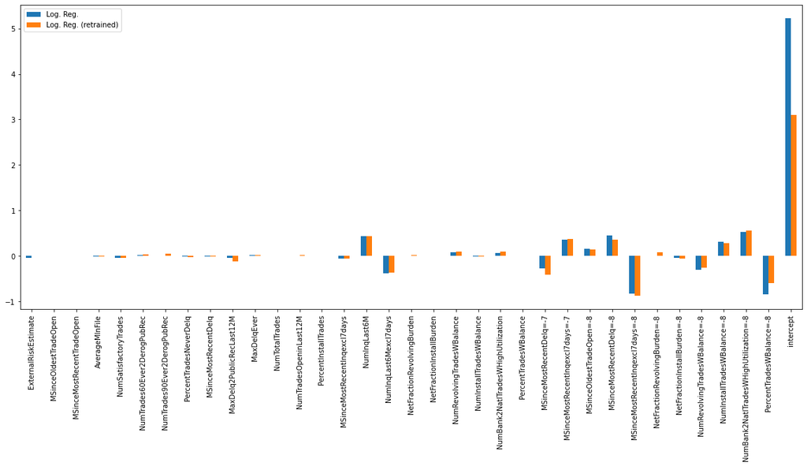

```python
pd.merge(linear_coefficients['Log. Reg.'],ANSWER_KEY['retrained_log_reg'], left_index=True, right_index=True).plot.bar(figsize=(20,8));
```

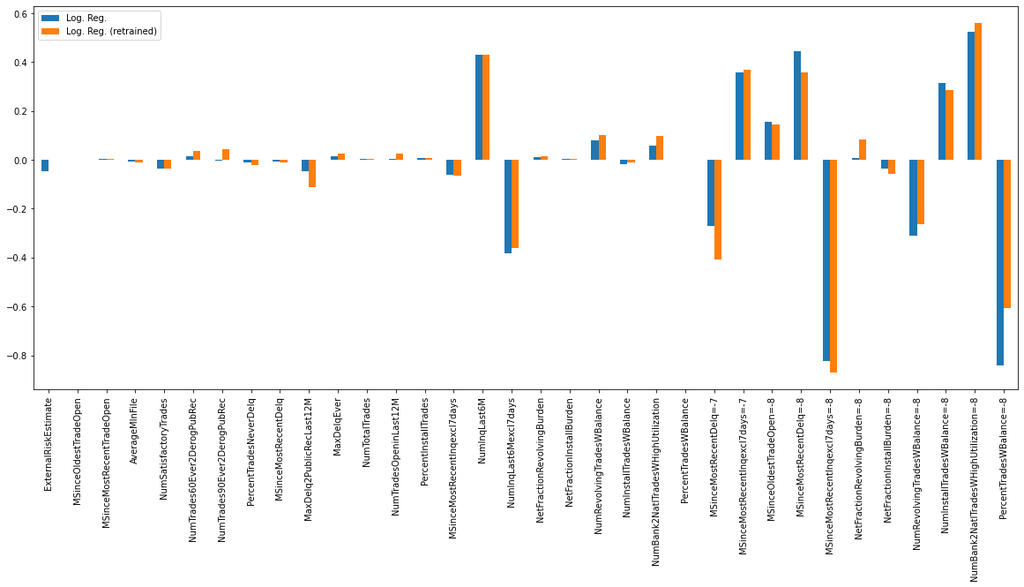

```python
# simliar plot only without the intercept
pd.merge(linear_coefficients['Log. Reg.'],ANSWER_KEY['retrained_log_reg'], left_index=True, right_index=True).iloc[:-1,:].plot.bar(figsize=(20,8));
```

The coefficients are somewhat different. It appears that training a logistic regression model without the feature `ExternalRiskEstimate` results in a redistribution of the coefficients.

It turns out that in practice, there are often multiple models whose performance is very similar. This, for example, could result from a correlation between features which allows using different subsets of features. It raises the question of which model to use?

Typical practical answers are:

- Use the simplest one. This is known as Occam's razor, and can be obtained by trial and error, regularization, stepwise selection (see Chapter 6 in Introduction in Statistical Learning), or integer programming based models (e.g., SLIM and RiskSLIM).
- Look carefully at the features used by each model and see which make more sense in the context of the specific prediction problem.

When debating between different models (trees vs. linear), one should consider the perspective of the user of the model and think about which one would be better suited for him or her for informing decisions.

**Estimating probabilities**

Finally, let's briefly explore some functionalities of probabilistic models. The logistic regression model not only makes predictions (1 vs. 0) but also estimates the probability that an observation is predicted as 1 or 0.

In sk-learn, the function `predict` returns a discrete prediction while the function `predict_proba` returns probability.

```python
# make predictions about observations 0 and 1 in the validation set
log_reg.predict(X_train_t_val.iloc[[0,1],:])
```

```
array([1, 0])
```

```python
#  compute probabilities corresponding to observation 0 and 1 in the validation set
print(log_reg.predict_proba(X_train_t_val.iloc[[0,1],:]))
```

```
[[0.17857207 0.82142793]
 [0.60071492 0.39928508]]
```

The probability that the label associated with observation #0 is 1, is equal to 0.82, which is greater than 0.5 and therefore the prediction is 1.

Let's look at the distribution of predictions. We will bucket observations according to the probabilities estimated by the model, and compute the accuracy in each bucket.

### q6

Create the dataframe `df_probs` which holds the following information about the validation set `X_train_t_val`:

1. `Prob(0)` - the probability that the model `log_reg` estimates for the label 0
2. `Prob(1)` - the probability that the model `log_reg` estimates for the label 1
3. `Prediction` - the prediction
4. `Label` - the true label
5. `Correct prediction` - is the prediction correct

An example of the output is provided below.

**Use may the function `log_reg.predict_proba` to compute probabilities.**

```python
# Get predicted probabilities for each class
probs = log_reg.predict_proba(X_train_t_val)

# Create the dataframe with required columns
df_probs = pd.DataFrame({
    "Prob(0)": probs[:, 0],  # Probability of class 0
    "Prob(1)": probs[:, 1],  # Probability of class 1
    "Prediction": log_reg.predict(X_train_t_val),  # Model predictions
    "Label": Y_train_t_val.values,  # True labels
    "Correct prediction": (log_reg.predict(X_train_t_val) == Y_train_t_val).astype(bool)  # Ensure boolean type
})

# Reset index to match expected output
df_probs = df_probs.reset_index(drop=True)

# Display the first few rows
print(df_probs.head())
```

```
    Prob(0)   Prob(1)  Prediction  Label  Correct prediction
0  0.178572  0.821428           1      1                True
1  0.600715  0.399285           0      0                True
2  0.415487  0.584513           1      1                True
3  0.874909  0.125091           0      0                True
4  0.768078  0.231922           0      0                True
```

```python
# expected output
ANSWER_KEY['df_probs'].head()
```

|  | Prob(0) | Prob(1) | Prediction | Label | Correct prediction |
| --- | --- | --- | --- | --- | --- |
| 0 | 0.1786 | 0.8214 | 1 | 1 | True |
| 1 | 0.6007 | 0.3993 | 0 | 0 | True |
| 2 | 0.4155 | 0.5845 | 1 | 1 | True |
| 3 | 0.8749 | 0.1251 | 0 | 0 | True |
| 4 | 0.7681 | 0.2319 | 0 | 0 | True |

```python
### BEGIN TEST (DO NOT REMOVE CELL) (required handling rounding)
sol = ANSWER_KEY['df_probs']
diff = sol.loc[:,"Correct prediction"].compare(df_probs.loc[:,"Correct prediction"], keep_equal=False, align_axis=0)
assert(len(diff)==0), 'testing "Correct prediction" column of df_probs'

diff = pd.Series({"Prob(0)" : True,
                  "Prob(1)" : True,
                  "Prediction" : True,
                  "Label" : True}).compare(((ANSWER_KEY['df_probs'].iloc[:,:-1] - df_probs.iloc[:,:-1]).abs() <= 0.01).all(), keep_equal=False)
assert(len(diff)==0), 'testing remaining columns of df_probs'
### END TEST
```

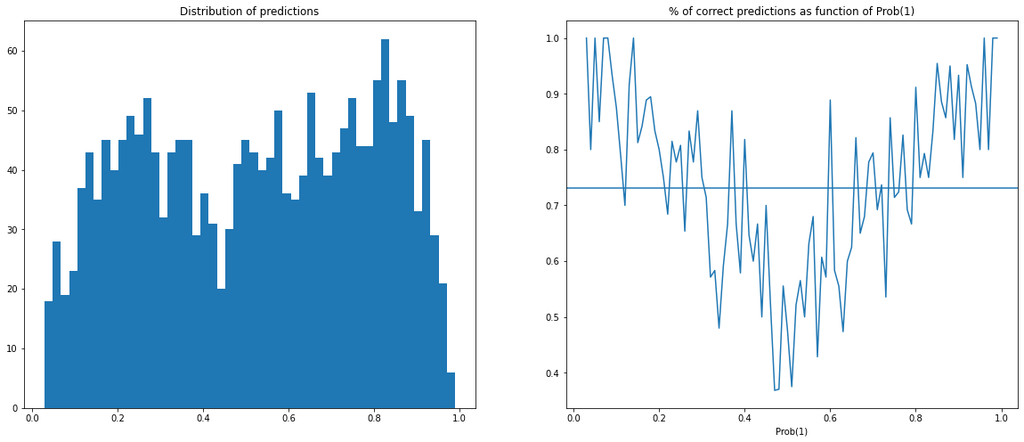

```python
fig,axes = plt.subplots(1,2,figsize=(20,8))
axes[0].hist(ANSWER_KEY['df_probs']['Prob(1)'], bins=50)
axes[0].set_title('Distribution of predictions')
ANSWER_KEY['df_probs'].round(2).groupby('Prob(1)').mean()['Correct prediction'].plot(ax=axes[1], title='% of correct predictions as function of Prob(1)');
axes[1].axhline(ANSWER_KEY['df_probs']['Correct prediction'].mean());
```

The figure shows that in many cases (when the probability is sufficiently small or large; see the histogram on the left), we are more confident about the model predictions (that's when the percentage of correct predictions is high).

However, there are also many observations for which the probability is close to 0.5. In these cases we are less confident about our predictions (on the right figure we see that prediction accuracy drops when the probability is around 0.5).

Intuitively, this is because observations for which the predicted probability is close to 0.5 are close to the decision boundary, an area where it is typically more difficult to classify.

## Part 2: Tree-based models

We now switch to working with tree-based models. Let's train a decision tree.

```python
from sklearn import tree
from sklearn.tree import DecisionTreeClassifier
from sklearn.ensemble import BaggingClassifier
from sklearn.ensemble import RandomForestClassifier
from sklearn.ensemble import AdaBoostClassifier
from sklearn.model_selection import train_test_split
from sklearn.model_selection import cross_val_score
from sklearn.model_selection import GridSearchCV
from sklearn.model_selection import StratifiedKFold
from IPython.display import Image
from IPython.display import IFrame
```

### q7 Decision trees

```python
clf_tree = DecisionTreeClassifier(max_depth=1, random_state=0).fit(X_train_t_tr, Y_train_t_tr)
```

Compute the train and validation accuracies and assign them to the variables `train_accuracy_DT` and `val_accuracy_DT`.

```python
# Compute training accuracy
train_accuracy_DT = clf_tree.score(X_train_t_tr, Y_train_t_tr)

# Compute validation accuracy
val_accuracy_DT = clf_tree.score(X_train_t_val, Y_train_t_val)

# Display results
print("Train Accuracy (Decision Tree):", train_accuracy_DT)
print("Validation Accuracy (Decision Tree):", val_accuracy_DT)
```

```
Train Accuracy (Decision Tree): 0.7156862745098039
Validation Accuracy (Decision Tree): 0.7068965517241379
```

```python
### BEGIN TEST
assert(np.isclose(ANSWER_KEY['train_accuracy_DT'], train_accuracy_DT, rtol=0, atol=0.01).all()), 'testing train_accuracy_DT'
### END TEST
```

```python
### BEGIN TEST
assert(np.isclose(ANSWER_KEY['val_accuracy_DT'], val_accuracy_DT, rtol=0, atol=0.01).all()), 'testing val_accuracy_DT'
### END TEST
```

```python
print('Train accuracy (DT): %.3f'%ANSWER_KEY['train_accuracy_DT'])
print('Validation accuracy (DT): %.3f'%ANSWER_KEY['val_accuracy_DT'])
```

```
Train accuracy (DT): 0.716
Validation accuracy (DT): 0.707
```

Let's visualize the tree

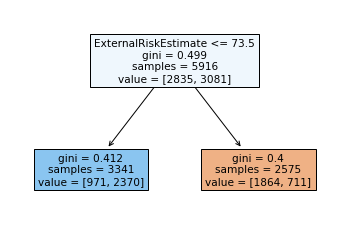

```python
tree.plot_tree(clf_tree, feature_names=column_names, filled=True)
plt.savefig("tree_stump.png", dpi=300)
```

The model is surprisingly accurate considering the fact that it is a decision stump (decision tree of depth 1), and that the accuracy is close to other models we previously trained on this dataset.

Let's see what happens when we change the depth of the tree. Initialize the variable `tree_accuracy` to a dataframe whose indexes run from 1 to 12, with two columns, one for `Train accuracy` and one for `Validation accuracy`. Use the default parameters of `DecisionTreeClassifier` except for the depth and setting `random_state=0`.

```python
# Define the range of depths to test
max_depth_range = range(1, 13)  # Depths from 1 to 12

# Initialize lists to store accuracy values
train_accuracies = []
val_accuracies = []

# Loop over different depths and train decision trees
for depth in max_depth_range:
    clf = DecisionTreeClassifier(max_depth=depth, random_state=0).fit(X_train_t_tr, Y_train_t_tr)

    # Compute accuracy on training and validation sets
    train_accuracies.append(clf.score(X_train_t_tr, Y_train_t_tr))
    val_accuracies.append(clf.score(X_train_t_val, Y_train_t_val))

# Create dataframe to store results
tree_accuracy = pd.DataFrame(
    {
        "Train accuracy": train_accuracies,
        "Validation accuracy": val_accuracies
    },
    index=max_depth_range
)


# Print first few rows for sanity check
print(tree_accuracy.head())
```

```
   Train accuracy  Validation accuracy
1        0.715686             0.706897
2        0.715686             0.706897
3        0.716362             0.699797
4        0.724814             0.708925
5        0.739351             0.706389
```

```python
# expected output
ANSWER_KEY['tree_accuracy'].head()
```

| Depth | Train accuracy | Validation accuracy |
| --- | --- | --- |
| 1 | 0.715686 | 0.706897 |
| 2 | 0.715686 | 0.706897 |
| 3 | 0.716362 | 0.699797 |
| 4 | 0.724814 | 0.708925 |
| 5 | 0.739351 | 0.706389 |

```python
### BEGIN TEST (DO NOT REMOVE CELL)
sol = ANSWER_KEY['tree_accuracy'].round(2)
diff = sol.compare(tree_accuracy.round(2), keep_equal=False, align_axis=0)
assert(len(diff)==0), 'testing tree_accuracy'
### END TEST
```

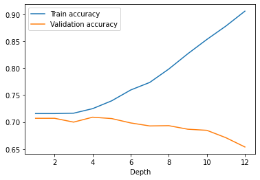

```python
ANSWER_KEY['tree_accuracy'].plot();
```

Plotting the train and validation accuracies as a function of the tree depth, we observe that there is no improvement the the validation accuracy (in fact there is a deterioration at some point), while the train accuracy keeps improving. This is an indication of overfitting. This is not surprising with decision trees which can perfectly classify any dataset with sufficient depth (as long as there are no two observations in the dataset with identical features and opposite predictions).

Let's try to tune the hyperparameters of the model to improve its performance.

```python
IFrame('https://scikit-learn.org/stable/modules/generated/sklearn.tree.DecisionTreeClassifier.html', width=950, height=300)
```

[interactive chart not shown]

```python
param_grid = [{'max_depth':range(1,13),
               'min_samples_leaf':[10,20,100],
               'max_leaf_nodes':[2,4,6,20,100,10000]}]

grid_search = GridSearchCV(DecisionTreeClassifier(random_state=0),
                           param_grid,
                           cv=StratifiedKFold(n_splits=5, shuffle=True, random_state=0),
                           scoring='accuracy')

grid_search.fit(X_train_t_tr, Y_train_t_tr)
```

```
GridSearchCV(cv=StratifiedKFold(n_splits=5, random_state=0, shuffle=True),
             estimator=DecisionTreeClassifier(random_state=0),
             param_grid=[{'max_depth': range(1, 13),
                          'max_leaf_nodes': [2, 4, 6, 20, 100, 10000],
                          'min_samples_leaf': [10, 20, 100]}],
             scoring='accuracy')
```

Read the documentation to see what each of the hyperparameters specified above does.

Create the dataframe `tree_accuracy_grid` based on the results of the grid search, which are stored in the variable `grid_search`. The dataframe should have a row per each configuration, and columns for the hyper parameters `max_depth`, `max_leaf_nodes`, `min_samples_leaf`, and `Accuracy`.

```python
# Extract results from the grid search
grid_results = pd.DataFrame(grid_search.cv_results_)

# Select relevant columns and rename them for clarity
tree_accuracy_grid = grid_results[
    ["param_max_depth", "param_max_leaf_nodes", "param_min_samples_leaf", "mean_test_score"]
].rename(columns={
    "param_max_depth": "max_depth",
    "param_max_leaf_nodes": "max_leaf_nodes",
    "param_min_samples_leaf": "min_samples_leaf",
    "mean_test_score": "Accuracy"
})

# Reset index for better formatting
tree_accuracy_grid = tree_accuracy_grid.reset_index(drop=True)
```

```python
# expected output
ANSWER_KEY['tree_accuracy_grid'].head()
```

|  | max_depth | max_leaf_nodes | min_samples_leaf | Accuracy |
| --- | --- | --- | --- | --- |
| 0 | 1 | 2 | 10 | 0.713491 |
| 1 | 1 | 2 | 20 | 0.713491 |
| 2 | 1 | 2 | 100 | 0.713491 |
| 3 | 1 | 4 | 10 | 0.713491 |
| 4 | 1 | 4 | 20 | 0.713491 |

```python
### BEGIN TEST (DO NOT REMOVE CELL)
sol = ANSWER_KEY['tree_accuracy_grid'].round(2)
diff = sol.compare(tree_accuracy_grid.round(2), keep_equal=False, align_axis=0)
assert(len(diff)==0), 'testing tree_accuracy_grid'
### END TEST
```

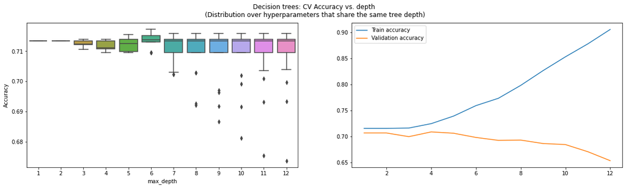

```python
fig, axes = plt.subplots(1,2,figsize=(20,5))
plt.suptitle('Decision trees: CV Accuracy vs. depth \n(Distribution over hyperparameters that share the same tree depth)')
sns.boxplot(x="max_depth", y='Accuracy', data=ANSWER_KEY['tree_accuracy_grid'], ax=axes[0]);
tree_accuracy.plot(ax=axes[1]);
```

The figure above shows the cross validation accuracy as a function of the maximal depth (since we're exploring many configuration, for each depth we have several configurations whose accuracies can be shown as a distribution). The right figure is identical to the figure presented earlier. Observe that the y-axis scale is different.

We see that with the right tuning, we can mitigate overfitting, which happens due to the increasing depth. However, it appears that we do not improve significantly the performance and we may simply select the decision stump.

### q8 Ensemble methods - Random forests

Instead of creating a single increasingly more complex tree, let's to create an ensemble of trees. Compute the train and validation accuracies of the Random Forest model below and assign them to the variables `train_accuracy_RF` and `val_accuracy_RF`.

```python
rf = RandomForestClassifier(max_depth=1, random_state=0).fit(X_train_t_tr, Y_train_t_tr)
```

```python
# Compute training and validation accuracies
train_accuracy_RF = rf.score(X_train_t_tr, Y_train_t_tr)
val_accuracy_RF = rf.score(X_train_t_val, Y_train_t_val)

# Display results
print("Train Accuracy (Random Forest):", train_accuracy_RF)
print("Validation Accuracy (Random Forest):", val_accuracy_RF)
```

```
Train Accuracy (Random Forest): 0.723630831643002
Validation Accuracy (Random Forest): 0.7155172413793104
```

```python
### BEGIN TEST
assert(np.isclose(ANSWER_KEY['train_accuracy_RF'], train_accuracy_RF, rtol=0, atol=0.01).all()), 'testing train_accuracy_RF'
### END TEST
```

```python
### BEGIN TEST
assert(np.isclose(ANSWER_KEY['val_accuracy_RF'], val_accuracy_RF, rtol=0, atol=0.01).all()), 'testing val_accuracy_RF'
### END TEST
```

```python
print('Train accuracy (RF): %.3f'%ANSWER_KEY['train_accuracy_RF'])
print('Validation accuracy (RF): %.3f'%ANSWER_KEY['val_accuracy_RF'])
```

```
Train accuracy (RF): 0.724
Validation accuracy (RF): 0.716
```

We gain a roughly 1% improvement comparing to the decision stump. Let's try to improve the model by performing hyper-parameter tuning. Read the documentation to see what each of the hyperparameters specified above does (https://scikit-learn.org/stable/modules/generated/sklearn.ensemble.RandomForestClassifier.html).

```python
param_grid = [{'n_estimators':[10,20,50],
               'max_depth':range(1,8),
               'min_samples_leaf':[10,20,100],
               'max_leaf_nodes':[2,4,8,16]}]

grid_search = GridSearchCV(RandomForestClassifier(random_state=0),
                           param_grid,
                           cv=StratifiedKFold(n_splits=5, shuffle=True, random_state=0),
                           scoring='accuracy')

grid_search.fit(X_train_t_tr, Y_train_t_tr)
```

```
GridSearchCV(cv=StratifiedKFold(n_splits=5, random_state=0, shuffle=True),
             estimator=RandomForestClassifier(random_state=0),
             param_grid=[{'max_depth': range(1, 8),
                          'max_leaf_nodes': [2, 4, 8, 16],
                          'min_samples_leaf': [10, 20, 100],
                          'n_estimators': [10, 20, 50]}],
             scoring='accuracy')
```

Create the dataframe `rf_accuracy_grid` based on the results of the grid search, which are stored in the variable `grid_search`. The dataframe should have a row per each configuration, and columns for the hyper parameters `n_estimators`, `max_depth`, `max_leaf_nodes`, `min_samples_leaf`, and `Accuracy`.

```python
# Extract results from the grid search
grid_results_rf = pd.DataFrame(grid_search.cv_results_)

# Select relevant columns and rename them for clarity
rf_accuracy_grid = grid_results_rf[
    ["param_n_estimators", "param_max_depth", "param_max_leaf_nodes", "param_min_samples_leaf", "mean_test_score"]
].rename(columns={
    "param_n_estimators": "n_estimators",
    "param_max_depth": "max_depth",
    "param_max_leaf_nodes": "max_leaf_nodes",
    "param_min_samples_leaf": "min_samples_leaf",
    "mean_test_score": "Accuracy"
})

# Reset index for better formatting
rf_accuracy_grid = rf_accuracy_grid.reset_index(drop=True)

# Display first few rows
print(rf_accuracy_grid.head())
```

```
  n_estimators max_depth max_leaf_nodes min_samples_leaf  Accuracy
0           10         1              2               10  0.703012
1           20         1              2               10  0.720592
2           50         1              2               10  0.718733
3           10         1              2               20  0.703012
4           20         1              2               20  0.720592
```

```python
# expected output
ANSWER_KEY['rf_accuracy_grid'].head()
```

|  | n_estimators | max_depth | max_leaf_nodes | min_samples_leaf | Accuracy |
| --- | --- | --- | --- | --- | --- |
| 0 | 10 | 1 | 2 | 10 | 0.703012 |
| 1 | 20 | 1 | 2 | 10 | 0.720592 |
| 2 | 50 | 1 | 2 | 10 | 0.718733 |
| 3 | 10 | 1 | 2 | 20 | 0.703012 |
| 4 | 20 | 1 | 2 | 20 | 0.720592 |

```python
### BEGIN TEST (DO NOT REMOVE CELL)
sol = ANSWER_KEY['rf_accuracy_grid']
diff = sol.compare(rf_accuracy_grid, keep_equal=False, align_axis=0)
assert(len(diff)==0), 'testing rf_accuracy_grid'
### END TEST
```

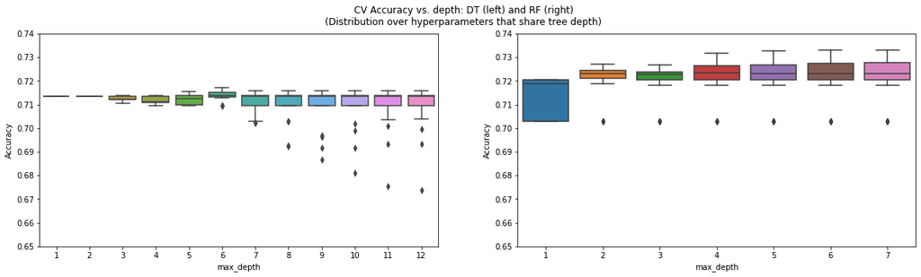

```python
fig, axes = plt.subplots(1,2,figsize=(20,5))
plt.suptitle('CV Accuracy vs. depth: DT (left) and RF (right)\n(Distribution over hyperparameters that share tree depth)')
sns.boxplot(x="max_depth", y='Accuracy', data=ANSWER_KEY['tree_accuracy_grid'], ax=axes[0]);
sns.boxplot(x="max_depth", y='Accuracy', data=ANSWER_KEY['rf_accuracy_grid'], ax=axes[1]);
axes[0].set_ylim(0.65,0.74);axes[1].set_ylim(0.65,0.74);
```

We see in the figure above that with some hyperparameter tuning we can further improve the accuracy of the RF model.

```python
# the best configuration
grid_search.best_params_
```

```
{'max_depth': 7,
 'max_leaf_nodes': 16,
 'min_samples_leaf': 100,
 'n_estimators': 10}
```

```python
# a model trained using the best configuration on all folds
best_RF_model = grid_search.best_estimator_
best_RF_model
```

```
RandomForestClassifier(max_depth=7, max_leaf_nodes=16, min_samples_leaf=100,
                       n_estimators=10, random_state=0)
```

Compute the train and validation accuracies of the optimized Random Forest `best_RF_model` and assign them to the variables `train_accuracy_RF_opt` and `val_accuracy_RF_opt`.

```python
# Compute training accuracy for the optimized RF model
train_accuracy_RF_opt = best_RF_model.score(X_train_t_tr, Y_train_t_tr)

# Compute validation accuracy for the optimized RF model
val_accuracy_RF_opt = best_RF_model.score(X_train_t_val, Y_train_t_val)

# Display results
print("Train Accuracy (Optimized Random Forest):", train_accuracy_RF_opt)
print("Validation Accuracy (Optimized Random Forest):", val_accuracy_RF_opt)
```

```
Train Accuracy (Optimized Random Forest): 0.7408722109533469
Validation Accuracy (Optimized Random Forest): 0.7200811359026369
```

```python
### BEGIN TEST
assert(np.isclose(ANSWER_KEY['train_accuracy_RF_opt'], train_accuracy_RF_opt, rtol=0, atol=0.01).all()), 'testing train_accuracy_RF_opt'
### END TEST
```

```python
### BEGIN TEST
assert(np.isclose(ANSWER_KEY['val_accuracy_RF_opt'], val_accuracy_RF_opt, rtol=0, atol=0.01).all()), 'testing val_accuracy_RF_opt'
### END TEST
```

```python
print('Train accuracy (RF optimized): %.3f'%ANSWER_KEY['train_accuracy_RF_opt'])
print('Validation accuracy (RF optimized): %.3f'%ANSWER_KEY['val_accuracy_RF_opt'])
```

```
Train accuracy (RF optimized): 0.741
Validation accuracy (RF optimized): 0.720
```

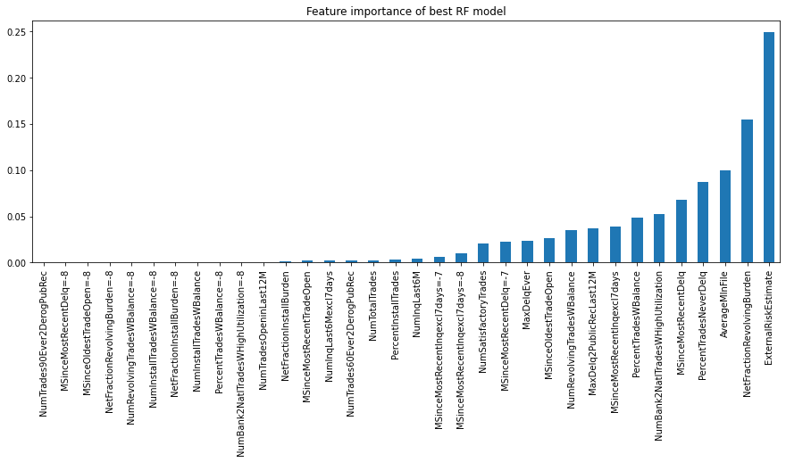

```python
# plot feature importance
pd.Series(data=grid_search.best_estimator_.feature_importances_,
          index=column_names).sort_values().plot.bar(figsize=(15,5),
                                                     title='Feature importance of best RF model');
```

It seems that our RF model still heavily relies on the feature `ExternalRiskEstimate`, but now it also utilizes other features.

Let's see how the CV accuracy is affected by the number of trees in the ensemble. Initialize the variable `rf_accuracy` to a dataframe whose indexes run from 10 to 190 with increments of 10, with two columns, one for `Train accuracy` and one for `Validation accuracy`. You should create the RF classifiers as follows: `RandomForestClassifier(n_estimators=?, random_state=0, max_depth=1)` where ? is replaced by the ensemble size.

```python
# Define the range of n_estimators to test
n_estimators_range = range(10, 200, 10)  # From 10 to 190 with step of 10

# Initialize lists to store accuracy values
train_accuracies_rf = []
val_accuracies_rf = []

# Loop over different numbers of trees and train RF classifiers
for n in n_estimators_range:
    rf_model = RandomForestClassifier(n_estimators=n, random_state=0, max_depth=1).fit(X_train_t_tr, Y_train_t_tr)

    # Compute accuracy on training and validation sets
    train_accuracies_rf.append(rf_model.score(X_train_t_tr, Y_train_t_tr))
    val_accuracies_rf.append(rf_model.score(X_train_t_val, Y_train_t_val))

# Create dataframe to store results
rf_accuracy = pd.DataFrame(
    {
        "Train accuracy": train_accuracies_rf,
        "Validation accuracy": val_accuracies_rf
    },
    index=n_estimators_range
)

# Display first few rows for sanity check
print(rf_accuracy.head())
```

```
    Train accuracy  Validation accuracy
10        0.704868             0.694726
20        0.720926             0.712982
30        0.720926             0.710446
40        0.720419             0.709432
50        0.719912             0.708418
```

```python
ANSWER_KEY['rf_accuracy'].head()
```

| n_estimators | Train accuracy | Validation accuracy |
| --- | --- | --- |
| 10 | 0.704868 | 0.694726 |
| 20 | 0.720926 | 0.712982 |
| 30 | 0.720926 | 0.710446 |
| 40 | 0.720419 | 0.709432 |
| 50 | 0.719912 | 0.708418 |

```python
### BEGIN TEST (DO NOT REMOVE CELL)
sol = ANSWER_KEY['rf_accuracy'].round(2)
diff = sol.compare(rf_accuracy.round(2), keep_equal=False, align_axis=0)
assert(len(diff)==0), 'testing rf_accuracy'
### END TEST
```

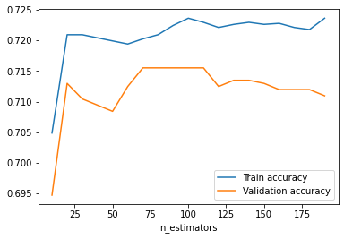

```python
ANSWER_KEY['rf_accuracy'].plot();
```

We observe that the performance of the ensemble tends to initially improve and then stabilizes as the ensemble grows.

### q9 Ensemble methods - Boosting

Let's to create another ensemble of trees, this time using Boosting. Compute the train and validation accuracies of the Boosting model below and assign them to the variables `train_accuracy_boosting` and `val_accuracy_boosting`.

```python
clf_boosting = AdaBoostClassifier(random_state=0).fit(X_train_t_tr, Y_train_t_tr)
```

```python
# Train an AdaBoost classifier
clf_boosting = AdaBoostClassifier(random_state=0).fit(X_train_t_tr, Y_train_t_tr)

# Compute training accuracy
train_accuracy_boosting = clf_boosting.score(X_train_t_tr, Y_train_t_tr)

# Compute validation accuracy
val_accuracy_boosting = clf_boosting.score(X_train_t_val, Y_train_t_val)

# Display results
print("Train Accuracy (Boosting):", train_accuracy_boosting)
print("Validation Accuracy (Boosting):", val_accuracy_boosting)
```

```
Train Accuracy (Boosting): 0.7489858012170385
Validation Accuracy (Boosting): 0.7276876267748479
```

```python
    ### BEGIN TEST
assert(np.isclose(ANSWER_KEY['train_accuracy_boosting'], train_accuracy_boosting, rtol=0, atol=0.01).all()), 'testing train_accuracy_boosting'
### END TEST
```

```python
### BEGIN TEST
assert(np.isclose(ANSWER_KEY['val_accuracy_boosting'], val_accuracy_boosting, rtol=0, atol=0.01).all()), 'testing val_accuracy_boosting'
### END TEST
```

```python
print('Train accuracy (boosting): %.3f'%ANSWER_KEY['train_accuracy_boosting'])
print('Validation accuracy (boosting): %.3f'%ANSWER_KEY['val_accuracy_boosting'])
print('\nTrain accuracy (RF optimized): %.3f'%ANSWER_KEY['train_accuracy_RF_opt'])
print('Validation accuracy (RF optimized): %.3f'%ANSWER_KEY['val_accuracy_RF_opt'])
print('\nTrain accuracy (DT): %.3f'%ANSWER_KEY['train_accuracy_DT'])
print('Validation accuracy (DT): %.3f'%ANSWER_KEY['val_accuracy_DT'])
```

```
Train accuracy (boosting): 0.749
Validation accuracy (boosting): 0.728

Train accuracy (RF optimized): 0.741
Validation accuracy (RF optimized): 0.720

Train accuracy (DT): 0.716
Validation accuracy (DT): 0.707
```

Using the default hyperparameters, we created an ensemble model that outperforms the previous models. This will not always be the case, and one should not conclude that Boosting is always superior to Random Forests.

There are several important hyperparameters for tuning the Boosting algorithm. One is the `base_estimator` which refers to the base model that we repeatedly train on (slight variations of) the data. The other two are `n_estimators` and `learning_rate` which go together. The first controlling the size of the ensemble (e.g., number of trees), and the second is the "step size", intuitively indicating the importance we give to each model. The smaller the learning rate, the more iterations we may need to reach the optimal ensemble.

Let's illustrate the effect of using a small learning rate.

Initialize the variable `boosting_accuracy_learning_rate_0_01` to a dataframe whose indexes run from 10 to 190 with increments of 10, with two columns, one for `Train accuracy` and one for `Validation accuracy`. Create an AdaBoost classifier as follows: `AdaBoostClassifier(n_estimators=?, random_state=0, learning_rate=0.01)` where ? should be replaced by the ensemble size.

```python
# Define the range of n_estimators to test
n_estimators_range = range(10, 200, 10)  # From 10 to 190 with step of 10

# Initialize lists to store accuracy values
train_accuracies_boosting = []
val_accuracies_boosting = []

# Loop over different numbers of estimators and train Boosting classifiers
for n in n_estimators_range:
    boosting_model = AdaBoostClassifier(n_estimators=n, random_state=0, learning_rate=0.01).fit(X_train_t_tr, Y_train_t_tr)

    # Compute accuracy on training and validation sets
    train_accuracies_boosting.append(boosting_model.score(X_train_t_tr, Y_train_t_tr))
    val_accuracies_boosting.append(boosting_model.score(X_train_t_val, Y_train_t_val))

# Create dataframe to store results
boosting_accuracy_learning_rate_0_01 = pd.DataFrame(
    {
        "Train accuracy": train_accuracies_boosting,
        "Validation accuracy": val_accuracies_boosting
    },
    index=n_estimators_range
)

# Display first few rows for sanity check
print(boosting_accuracy_learning_rate_0_01.head())
```

```
    Train accuracy  Validation accuracy
10        0.715686             0.706897
20        0.715686             0.706897
30        0.715686             0.706897
40        0.715686             0.706897
50        0.715686             0.706897
```

```python
ANSWER_KEY['boosting_accuracy_learning_rate_0_01'].head()
```

| n_estimators | Train accuracy | Validation accuracy |
| --- | --- | --- |
| 10 | 0.715686 | 0.706897 |
| 20 | 0.715686 | 0.706897 |
| 30 | 0.715686 | 0.706897 |
| 40 | 0.715686 | 0.706897 |
| 50 | 0.715686 | 0.706897 |

```python
### BEGIN TEST (DO NOT REMOVE CELL)
sol = ANSWER_KEY['boosting_accuracy_learning_rate_0_01'].round(2)
diff = sol.compare(boosting_accuracy_learning_rate_0_01.round(2), keep_equal=False, align_axis=0)
assert(len(diff)==0), 'testing boosting_accuracy_learning_rate_0_01'
### END TEST
```

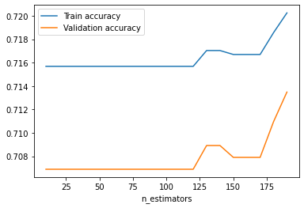

```python
ANSWER_KEY['boosting_accuracy_learning_rate_0_01'].plot();
```

Even though we trained an ensemble with 190 trees, the learning rate is small (0.01) and therefore we will need much larger ensembles to obtain better models (assuming we keep the same learning rate).

Let's try a higher learning rate and train a larger ensemble. Initialize the variable `boosting_accuracy_learning_rate_1` to a dataframe whose indexes run from 10 to 390 with increments of 10, with two columns, one for `Train accuracy` and one for `Validation accuracy`. Create an AdaBoost classifier as follows: `AdaBoostClassifier(n_estimators=?, random_state=0, learning_rate=1)` where ? should be replaced by the ensemble size.

```python
# Define the range of n_estimators to test
n_estimators_range = range(10, 400, 10)  # From 10 to 390 with step of 10

# Initialize lists to store accuracy values
train_accuracies_boosting = []
val_accuracies_boosting = []

# Loop over different numbers of estimators and train Boosting classifiers
for n in n_estimators_range:
    boosting_model = AdaBoostClassifier(n_estimators=n, random_state=0, learning_rate=1).fit(X_train_t_tr, Y_train_t_tr)

    # Compute accuracy on training and validation sets
    train_accuracies_boosting.append(boosting_model.score(X_train_t_tr, Y_train_t_tr))
    val_accuracies_boosting.append(boosting_model.score(X_train_t_val, Y_train_t_val))

# Create dataframe to store results
boosting_accuracy_learning_rate_1 = pd.DataFrame(
    {
        "Train accuracy": train_accuracies_boosting,
        "Validation accuracy": val_accuracies_boosting
    },
    index=n_estimators_range
)

# Display first few rows for sanity check
print(boosting_accuracy_learning_rate_1.head())
```

```
    Train accuracy  Validation accuracy
10        0.732082             0.716024
20        0.740196             0.720588
30        0.744591             0.722110
40        0.746619             0.722617
50        0.748986             0.727688
```

```python
ANSWER_KEY['boosting_accuracy_learning_rate_1'].head()
```

| n_estimators | Train accuracy | Validation accuracy |
| --- | --- | --- |
| 10 | 0.732082 | 0.716024 |
| 20 | 0.740196 | 0.720588 |
| 30 | 0.744591 | 0.722110 |
| 40 | 0.746619 | 0.722617 |
| 50 | 0.748986 | 0.727688 |

```python
### BEGIN TEST (DO NOT REMOVE CELL)
sol = ANSWER_KEY['boosting_accuracy_learning_rate_1'].round(2)
diff = sol.compare(boosting_accuracy_learning_rate_1.round(2), keep_equal=False, align_axis=0)
assert(len(diff)==0), 'testing boosting_accuracy_learning_rate_1'
### END TEST
```

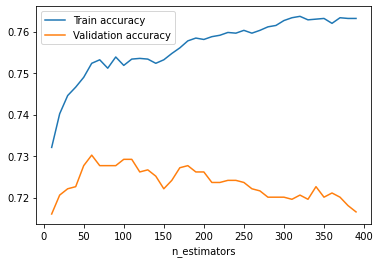

```python
ANSWER_KEY['boosting_accuracy_learning_rate_1'].plot();
```

Now that the learning rate is sufficiently large, we achieve the optimal ensemble size using approximately 60 trees. Beyond that point, we start to overfit: the training accuracy keeps improving while the validation accuracy worsens as the ensemble grows.

Note that simliarly to linear models where there are many linear models that work differently, there are also many variants of the Boosting algorithm. See, for example, [sk-learn](https://scikit-learn.org/stable/modules/ensemble.html), [XGBoost](https://xgboost.readthedocs.io/en/latest/), and LightGBM.

# Summary

In this homework assignment, we experimented with linear and tree-based models and their key hyper-parameters to observe how they affect the resulting models.

```python
###
### AUTOGRADER TEST - DO NOT REMOVE
###
```